# Generating Random Variables

Stefan Dan,

2023-05-17

Generating U(a,b) from U(0,1)

```r
U <- function(n, a, b){
  a + (b-a)*runif(n);
}
print(U(10, 2, 6))
```

```
##  [1] 4.822537 5.016049 3.625302 5.852910 2.478077 2.013086 2.973618 2.112144
##  [9] 3.760287 2.385748
```

Simulation checks

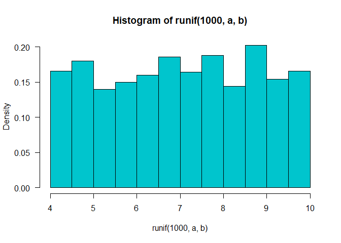

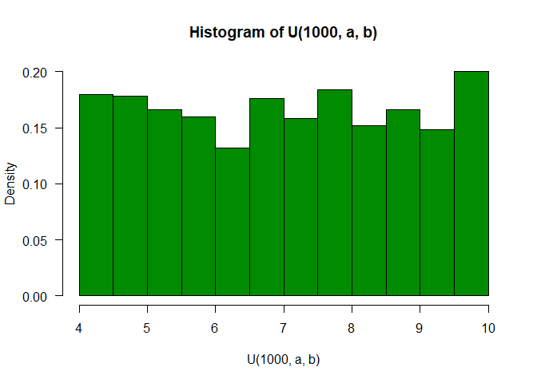

```r
a = 4; b = 10;
# prob = T switches y-axis to density
# las = 1 sets the y-axis values vertically
hist(runif(1000, a, b), prob = T, col = "turquoise3", las = 1)
hist(U(1000, a, b), prob = T, col = "green4", las = 1)
```

## Inverse transform method

Use the fact that the cdf of $F_x(x)$ is the same as the cdf of $U(0,1)$, i.e $F_x(x) \sim U(0,1)$ if $F_x(x)$ is invertible and we can derive the formula analytically, then we can generate random variables using

1. Generate $U \sim U(0,1)$
2. Set $X = F^{-1}_x(u)$

More generally, $F^{-1}_x(u) = \inf_x\{F_x(x)=u\}$

Example: Generate exponentially distributed random variables $X \sim exp(\lambda)$ pdf: $f(x) = \lambda e^{-\lambda x }$ with $x \in (0, \infty)$ A quick calculation shows cdf: $F_x(x) = 1 - e^{-\lambda x}$ quantile: $F_x^{-1}(x) = -\ln(1-x)/\lambda$

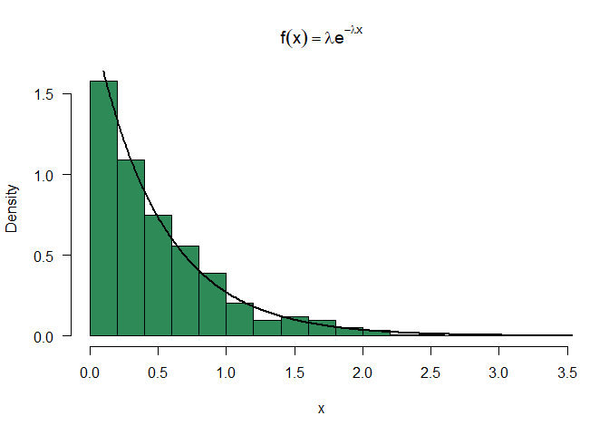

```r
lambda = 2
u = runif(1000)
x = -log(u)/lambda

hist(x, prob = T, las = 1, col="seagreen4",breaks =20,
     main = latex2exp::TeX('$f(x) = \\lambda e^{-\\lambda x }$'))
y = seq(0,4, .01)
lines(y, lambda*exp(-lambda*y), lwd = 2)
```

$X$ is standard double-exponential distributed i.e $f(x) = \frac{1}{2}e^{|x|}$ One gets $F_X(x) = \frac{1}{2}e^{x}$ if $x \leq 0$

and $F_X(x) = 1-\frac{1}{2}e^{-x}$ if $x>0$

Therefore, $F_X^{-1}(p) = \log(2p)$ if $p\leq 0.5$

and $F_X^{-1}(p) = -\log(2(1-p))$ if $p>0.5$

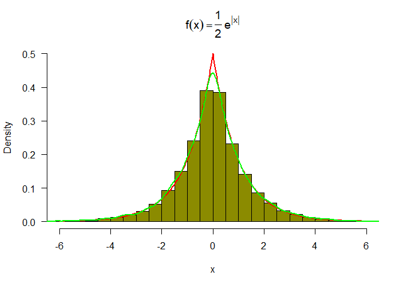

```r
coolerQ <- function(p){
  return(ifelse(p<=0.5, log(2*p), -log(2*(1-p))))
}
n=10000;
u = runif(n);
x = coolerQ(u);
hist(x, prob = T, las = 1, col="yellow4", breaks = 60,
     main = latex2exp::TeX('$f(x) = \\frac{1}{2}e^{|x|}$'),ylim=c(0,0.5), xlim=c(-6,6))
y = seq(-6,6,.02);
lines(y, 0.5*exp(-abs(y)),lwd = 2, col="red")
d <- density(x);
lines(d, lwd =2, col="green")
```

Comparison between empirical and theoretical quantiles

```r
p = seq(0.1, 0.9, by = 0.1)
sampleqs = quantile(x,p);
theoryqs = coolerQ(p);
se = sqrt(p*(1-p)/(n*(1/2*exp(-abs(theoryqs)))^2));
devs = round(cbind((sampleqs-theoryqs)/se),2);
df <- data.frame(p,sampleqs,theoryqs,se, devs)
print(df)
```

```
##       p    sampleqs   theoryqs         se  devs
## 10% 0.1 -1.63714912 -1.6094379 0.03000000 -0.92
## 20% 0.2 -0.95050177 -0.9162907 0.02000000 -1.71
## 30% 0.3 -0.52971529 -0.5108256 0.01527525 -1.24
## 40% 0.4 -0.23356109 -0.2231436 0.01224745 -0.85
## 50% 0.5 -0.01022407  0.0000000 0.01000000 -1.02
## 60% 0.6  0.21807266  0.2231436 0.01224745 -0.41
## 70% 0.7  0.50715666  0.5108256 0.01527525 -0.24
## 80% 0.8  0.92364091  0.9162907 0.02000000  0.37
## 90% 0.9  1.64457773  1.6094379 0.03000000  1.17
```

## Acceptance-Rejection Method

Example: Generate $X \sim N(0,1)$ using Student t distribution with 2 degrees of freedom:

$g(x) = \frac{\Gamma(3/2)}{\sqrt{2\pi}}(1+x^2/2)^{-3/2}$

$f(x) = \frac{1}{\sqrt{2\pi}}e^{-x^2/2}$ Find a maximal constant $c$ such that $\frac{f(x)}{g(x)}\leq c$ for all $x$. After rather long calculation one finds

$c = \frac{(3/2)^{3/2}}{\Gamma(3/2)e^{1/2}} \approx 1.25731677$

The Algorithm:

1. Generate $Y \sim g$
2. Generate $U \sim U(0,1)$
3. if $U \leq \frac{f(Y)}{cg(Y)}$ then accept $Y$ and return, else reject $Y$ and try again.

Notes: $P(accept) = \frac{1}{c}$

$P(accept|Y=y) = \frac{f(y)}{cg(y)}$

The smaller the $c$, the better is the acceptance rate on average. If in some regions, the distance between $f$ and $g$ is very big, then the acceptance rate there will be very low and thus the sample we generate will most likely be skewed.

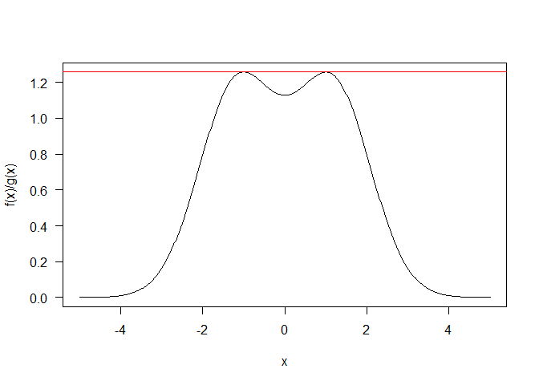

```r
f <- function(x){
  return(1/sqrt(2*pi)*exp(-x^2/2))
}
g <- function(x){
  return(gamma(3/2)/(sqrt(2*pi)*(1+x^2/2)^(3/2)))
}


x = seq(-5, 5, by = 0.02)
plot(x, f(x)/g(x), type = 'l', las =1)

c = (3/2)^(3/2)/(1/2*sqrt(pi)*exp(1/2))
abline(h = c, col ='red')
```

Plot of $f$ and of the cover density $cg$

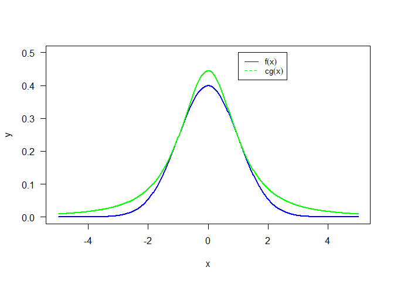

```r
plot(x, f(x), type = 'l', las = 1, lwd = 2, col = 'blue', ylim = c(0,0.5), ylab ='y')
lines(x, g(x)*c, type = 'l', lwd = 2, col='green')
legend(1, 0.5, legend=c(latex2exp::TeX('$f(x)$'), latex2exp::TeX('$cg(x)$')),
       col=c("blue","green"), lty=1:2, cex=0.8)
```

Algorithm to generate $n=1000$ standard normally distributed random variables using this approach:

```r
n = 1000;
k = 0;             # number of accepted rvs
niter = 0;         #number of iterations needed
x = numeric(n);    # target samples
while(k<n){
  niter = niter + 1;
  y = rt(n=1,df=2);
  u = runif(1);
  if(u<= f(y)/(c*g(y))){
    k = k+1;
    x[k] = y;
  }
}
print(paste("Number of iterations needed: ", niter));
```

```
## [1] "Number of iterations needed:  1263"
```

```r
print(paste("Expected number of iterations needed: ", n*c));
```

```
## [1] "Expected number of iterations needed:  1257.31676643423"
```

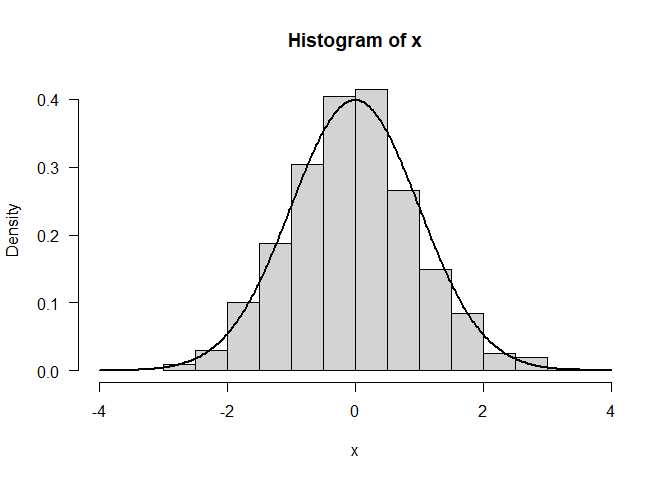

```r
hist(x, prob = T, las = 1, breaks = 20, xlim = c(-4, 4));
y = seq(-4,4, by = 0.02);
lines(y, f(y), lwd = 2)
```

Empirical versus theoretical quantiles analysis

```r
p = seq(0.1, 0.9, by = 0.1)
theoryqs = qnorm(p)
sampleqs = quantile(x, p)
se = sqrt(p*(1-p)/(n*dnorm(theoryqs)^2))
devs = round(cbind((sampleqs-theoryqs)/se),2);
df <- data.frame(p,sampleqs,theoryqs,se, devs)
print(df)
```

```
##       p   sampleqs   theoryqs         se  devs
## 10% 0.1 -1.2689753 -1.2815516 0.05405654  0.23
## 20% 0.2 -0.8584388 -0.8416212 0.04518154 -0.37
## 30% 0.3 -0.5445208 -0.5244005 0.04167870 -0.48
## 40% 0.4 -0.2706915 -0.2533471 0.04009896 -0.43
## 50% 0.5 -0.0338369  0.0000000 0.03963327 -0.85
## 60% 0.6  0.2414041  0.2533471 0.04009896 -0.30
## 70% 0.7  0.4592912  0.5244005 0.04167870 -1.56
## 80% 0.8  0.7267432  0.8416212 0.04518154 -2.54
## 90% 0.9  1.2304779  1.2815516 0.05405654 -0.94
```

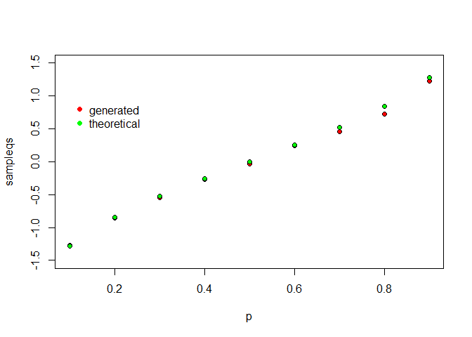

```r
plot(p, sampleqs, bg = 'red', pch = 21 , ylim = c(-1.5, 1.5))
points(p, theoryqs, bg = 'green', pch = 21)
legend(0.1, 1, legend=c("generated", "theoretical"),
       col=c("red","green"), pch=c(16,16), bty='n')
```

## Transformation methods

Relationships between common distributions

1. $Z \sim N(0,1) \implies Z^2 \sim \chi_1^2$
2. $U \sim \chi_m^2 , V \sim \chi_n^2 \text{ independent} \implies \frac{U/m}{V/n} \sim F_{m,n}$
3. $Z \sim N(0,1), U \sim \chi_n^2 \text{ independent} \implies \frac{Z}{\sqrt{U/n}} \sim t_n$
4. $U \sim Gamma(\alpha,\lambda), V \sim Gamma(\beta, \lambda) \text{ independent} \implies \frac{U}{U+V} \sim Beta(\alpha, \beta)$

#### Example

Generate 1000 random variables from the F distribution with $m, n$ degrees of freedom using the *rchisq* function for $(m,n) = (1,3), (10,10), (100,100)$

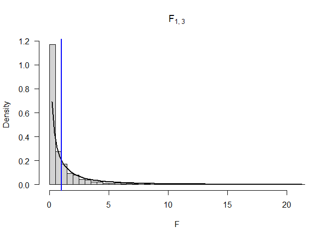

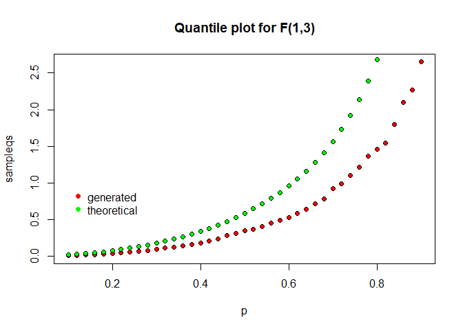

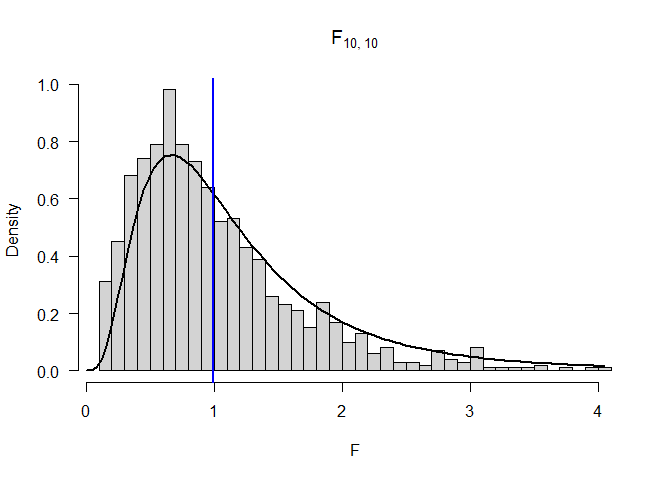

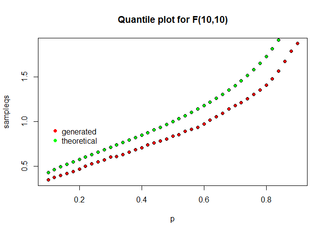

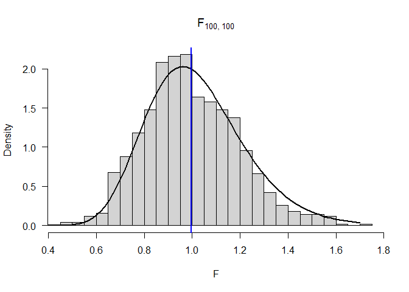

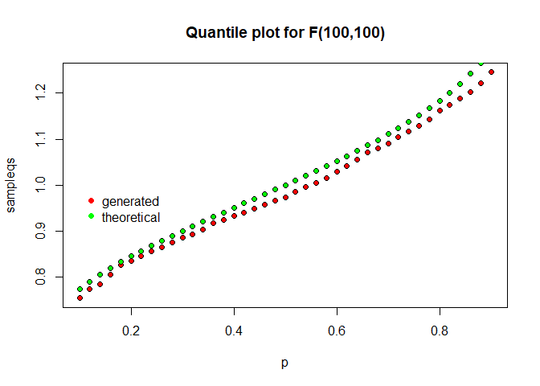

```r
f <- function(N, m , n){
  U = rchisq(N, m)
  V = rchisq(N, n)
  F = U/m*V/n
return(F)
}
N = 1000
m = c(1, 10, 100)
n = c(3, 10, 100)
for(i in 1:length(m)){
  F = f(N,m[i],n[i])
  new_title = paste0('$F_{', m[i],',', n[i], '}$', sep = '')
  hist(F,las = 1, prob = T, breaks = 40, main = latex2exp::TeX(new_title))
  x = seq(0,max(F), length.out = 100)
  lines(x, df(x, m[i], n[i]), lwd = 2)
  abline(v=mean(F), col='blue', lwd = 2)
  # quantile plot
  p = seq(0.1, 0.9, by = 0.02)
  theoryqs = qf(p, m[i],n[i])
  sampleqs = quantile(F, p)
  plot(p, sampleqs, bg = 'red', pch = 21, main = paste("Quantile plot for F(", m[i],',', n[i],")", sep =''))
  points(p, theoryqs, bg = 'green', pch = 21)
  legend(0.1, 1, legend=c("generated", "theoretical"),
       col=c("red","green"), pch=c(16,16), bty='n')

}
```

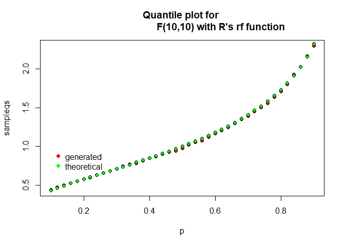

```r
m = 10
n = 10
F = rf(1000, m, n)
p = seq(0.1, 0.9, by = 0.02)
  theoryqs = qf(p, m, n)
  sampleqs = quantile(F, p)
  plot(p, sampleqs, bg = 'red', pch = 21, main = paste("Quantile plot for
                              F(", m,',', n,") with R's rf function", sep =''))
  points(p, theoryqs, bg = 'green', pch = 21)
  legend(0.1, 1, legend=c("generated", "theoretical"),
       col=c("red","green"), pch=c(16,16), bty='n')
```

## Sums and mixtures

The t-distribution with $v$ degrees of freedom is a continuous mixture $X|W \sim N(0, W)$ with $W\sim IG(\frac{v}{2}, \frac{v}{2})$, the inverse gamma distribution.

Task: generate 1000 random variables $t_4$-distributed.

Algorithm:

1. generate random variable U from the mixture distribution
2. generate random variable from the distribution with parameter U

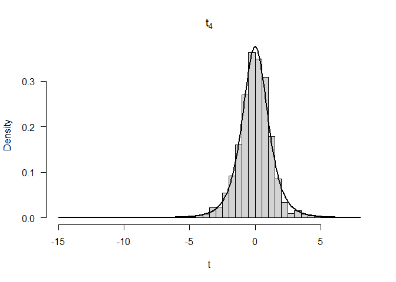

```r
N = 1000
v = 4
U = invgamma::rinvgamma(N, v/2, rate = v/2) # invgamma is quite dubious and switches scale and rate
t = rnorm(N, 0, sqrt(U))
hist(t, las = 1, prob = TRUE,  breaks = 40,
     main = latex2exp::TeX("$ t_4$"))
x = seq(min(t), max(t), length.out = 300)
lines(x, dt(x,df = v), lwd = 2)
```

```r
p = seq(0.1, 0.9, by = 0.1)
theoryqs = qt(p, v)
sampleqs = quantile(t, p)
se = sqrt(p*(1-p)/(N*dt(theoryqs, v)^2))
devs = round(cbind((sampleqs-theoryqs)/se),2);
df <- data.frame(p,sampleqs,theoryqs,se, devs)
print(df)
```

```
##       p     sampleqs   theoryqs         se  devs
## 10% 0.1 -1.569730768 -1.5332063 0.08035218 -0.45
## 20% 0.2 -0.937171892 -0.9409646 0.05560736  0.07
## 30% 0.3 -0.545848455 -0.5686491 0.04693344  0.49
## 40% 0.4 -0.284895250 -0.2707223 0.04323026 -0.33
## 50% 0.5 -0.001113484  0.0000000 0.04216370 -0.03
## 60% 0.6  0.290319036  0.2707223 0.04323026  0.45
## 70% 0.7  0.558470298  0.5686491 0.04693344 -0.22
## 80% 0.8  0.843985856  0.9409646 0.05560736 -1.74
## 90% 0.9  1.397320047  1.5332063 0.08035218 -1.69
```

##### Negative Binomial as mixture of Poisson and Gamma

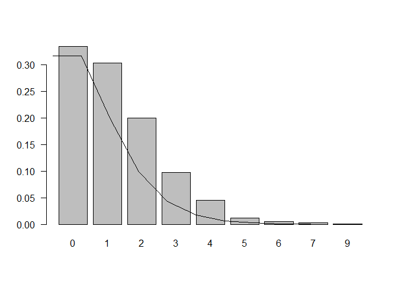

```r
N = 1000
r = 4
beta = 3
lambda = rgamma(N, r , beta)
x <- rpois(N, lambda)
barplot(table(x)/N, las = 1)
a = seq(0, max(x), by = 1)
lines(a, dnbinom(a, r, beta/(1+beta)))
```

```r
sim=table(x)/N
uniquex=sort(unique(x))
truth=dnbinom(uniquex,r,beta/(1+beta))
diff=sim-truth
twose=2*sqrt(truth*(1-truth)/N)
round(rbind(uniquex,sim,truth,diff,twose),3)
```

```
##             0      1     2      3     4      5      6     7     9
## uniquex 0.000  1.000 2.000  3.000 4.000  5.000  6.000 7.000 9.000
## sim     0.334  0.303 0.200  0.097 0.045  0.012  0.005 0.003 0.001
## truth   0.316  0.316 0.198  0.099 0.043  0.017  0.006 0.002 0.000
## diff    0.018 -0.013 0.002 -0.002 0.002 -0.005 -0.001 0.001 0.001
## twose   0.029  0.029 0.025  0.019 0.013  0.008  0.005 0.003 0.001
```

## Multivariate Normal distribution random variable generator

To generate $Y \sim N_p(\mu,\Sigma)$ from a sequence $Z_1, ... Z_p \sim N(0,1)$:

Algorithm: 1. Cholesky Decomposition: $\Sigma = Q^T*Q$. 2. Set $Z = (Z_1, Z_2,..., Z_p)^T \sim N_p(0,I)$. 3. Set $Y = Q^T * Z + \mu \sim N_p(\mu, \Sigma)$.

Here, an efficient method for $n$ random variables MVN-distributed:

```r
rmvnormal <- function(n, mu, sigma){
  p = length((mu));
  Q = chol(sigma);
  Z = matrix(rnorm(n*p), nrow = n);
  Y = Z%*%Q + matrix(mu, nrow = n, ncol = p, byrow = TRUE)
  return(Y)
}
```

Test: $\mu = (1,2)$ $\Sigma = \begin{bmatrix}2 & 1.2 \\ 1.2&5 \end{bmatrix}$

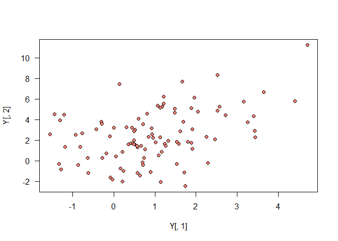

```r
# parameters
n= 100;
mu = c(1,2);
sigma = matrix(c(2, 1.2, 1.2, 5), nrow = 2);
# generate random variables
Y = rmvnormal(n, mu, sigma); # Y is n x 2 array; each line represents one rv

# plot
plot(Y[,1], Y[,2], las = 1, bg = "salmon", pch = 21)
```

```r
# checks:
sample_mu = round(apply(Y, 2, mean),2)
sample_sigma = round(cov(Y), 2)
print(sample_mu)
```

```
## [1] 0.94 2.39
```

```r
print(sample_sigma)
```

```
##      [,1] [,2]
## [1,] 1.65 1.37
## [2,] 1.37 6.39
```

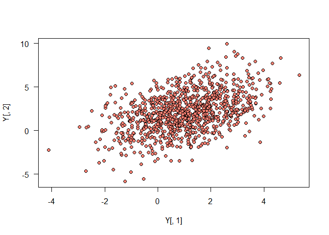

```r
n = 1000;
Y = rmvnormal(n, mu, sigma);
plot(Y[,1], Y[,2], las = 1, bg = "salmon", pch = 21)
```

```r
# checks:
sample_mu = round(apply(Y, 2, mean),2)
sample_sigma = round(cov(Y), 2)
print(sample_mu)
```

```
## [1] 1.03 2.08
```

```r
print(sample_sigma)
```

```
##      [,1] [,2]
## [1,] 2.00 1.43
## [2,] 1.43 5.18
```